# Cars4U Project

##### Checking for distribution of residuals

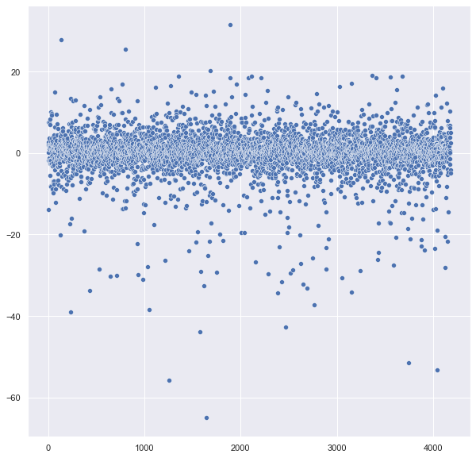

```python
# check heteroscedasticity TRAIN
train_residuals = linr_model.predict(x_train).flatten()-y_train['Price'].array
plt.figure(figsize=(10,10))
sns.scatterplot(y=train_residuals, x=(range(len(y_train))))
```

```python
train_residuals.sum()
```

```
-1.7053025658242404e-12
```

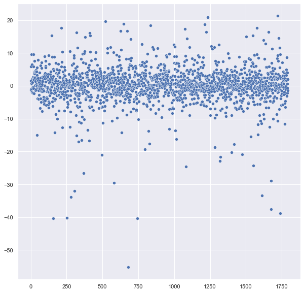

```python
# check heteroscedasticity TEST
test_residuals = linr_model.predict(x_test).flatten()-y_test['Price'].array
plt.figure(figsize=(10,10))
sns.scatterplot(y=test_residuals, x=(range(len(y_test))))
```

```python
test_residuals.sum()
```

```
299.8171454816109
```

The distributions of residuals look roughly randomly distributed but have outliers in the negative values.

### Conclusions

- A predictive model was built to predict cars prices with an $Adj. R^2$ of $0.718$ on the test set.
- The model can be used to predict cars prices with a mean absolute error of $3.53$ on the test set.
- The year of the car, the power and engine size are factors which tend to increase the price.  
  Note that engine size and power are strongly correlated (0.86).
- Mileage and Km_log (log of 'Kilometers_Driven') will lower the price of a car as they increase.
- For the purpose of differential pricing, it was found that Location is a factor that influences price, and suggests that price for the same car could be adjusted based on location, as customers might we willing to pay higher prices in certain locations.  
  E.g. Coimbatore, Hyderabad and Bangalore have price differentials of +1.7 to +2.2 as compared to the baseline location (Ahmedabad).
- Engine size (displacement) and power also have large coefficients, suggesting that customers are sensitive to those specifications. E.g. cars with high power and engine displacement could be priced higher.
- Because of the high number of different car models, that feature (derived from 'Name') was not used in training the linear model. It is probable that it has a high predictive power for price. Other non-linear models that can deal with high number of categorical values should be considered, as they might be more effective in predicting price.